# Machine Learning - Project

Marcel M.

4/26/2020

# HUMAN ACTIVITY RECOGNITION

## Introduction

Human activity recognition (HAR) involves predicting the movement of a person based on sensor data and traditionally involves deep domain expertise and methods from signal processing to correctly engineer features from the raw data in order to fit a machine learning model. This report aims at builting a model capable to predict how well people do a particular activity, which in this case is perfom barbell lifts. For the purpose of this project, a data set from accelerometers placed in different parts of 6 participants is used to predict the manner individuals performed the exercise.

## 1 Loading data

```r
setwd("C:/Users/Marcel/Documents/DataScience/Course8 - Machine Learning")
if(!dir.exists("Project_HAR")){
  dir.create("Project_HAR")
  setwd("Project_HAR")
  url_train = "https://d396qusza40orc.cloudfront.net/predmachlearn/pml-training.csv"
  url_test = "https://d396qusza40orc.cloudfront.net/predmachlearn/pml-testing.csv"
  download.file(url_train, "training.csv")
  download.file(url_test, "testing.csv")}

  setwd("Project_HAR")
  training = read.csv("training.csv")
  testing = read.csv("testing.csv")
```

## 2 Cross Validation: K-Folds

The cross-validation resampling procedure to evaluate the machine learning models splits the data sample in 10 groups (folds), as follows:

```r
library(caret)

CrossVal = trainControl(method = "cv", number = 10, classProbs = TRUE)
```

## 3 Feature Selection

### 3.1 Percentage of missing values

Drop variables that have a very high percentage of missing values.

```r
training <- training[, colMeans(is.na(training)) < .9]
```

### 3.2 Removing identification predictors.

```r
training = training[, -(1:5)]
```

### 3.3 Removing Near Zero Variance predictors.

Drop variables that have very low variation.

```r
NZV = nearZeroVar(training)
training = training[,-NZV]
```

### 3.4 Multicollinearity

The analysis of correlation indicates there are 22 predicators with correlation above 70% with other predictors. Multicollinearity might be harmful to prediction models and can be eliminated by PCA (Code in Appendix A).

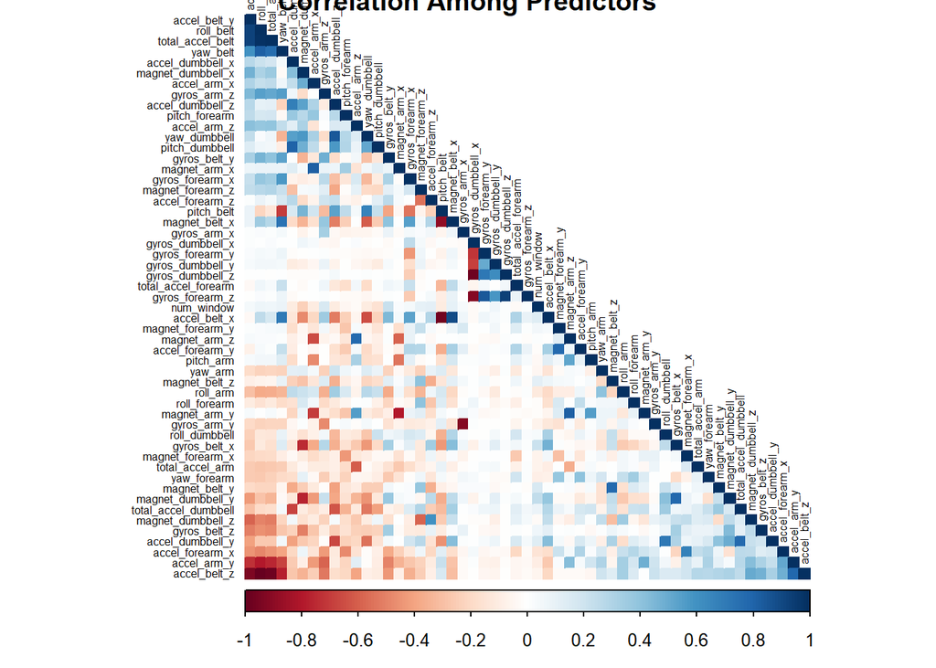

```
##  [1] "magnet_forearm_z"  "roll_belt"         "num_window"
##  [4] "magnet_forearm_y"  "pitch_belt"        "yaw_belt"
##  [7] "accel_belt_x"      "pitch_dumbbell"    "gyros_arm_x"
## [10] "gyros_belt_x"      "accel_forearm_z"   "gyros_forearm_y"
## [13] "gyros_belt_y"      "total_accel_belt"  "accel_belt_z"
## [16] "magnet_dumbbell_x" "accel_dumbbell_x"  "gyros_dumbbell_x"
## [19] "magnet_arm_z"      "accel_arm_y"       "magnet_arm_x"
## [22] "gyros_arm_z"
```

### 3.5 Coefficient of Variation

Almost half of the predictors (25 out of 53) present a high coefficient of variation (>1). This high variation can be corrected via standardizing, which also primes the data for the PCA pre-processing (Code in Appendix B).

```
##  [1] pitch_belt        gyros_belt_y      magnet_belt_x     roll_arm
##  [5] gyros_arm_x       gyros_arm_z       accel_arm_y       magnet_arm_x
##  [9] magnet_arm_y      magnet_arm_z      roll_dumbbell     yaw_dumbbell
## [13] gyros_dumbbell_x  gyros_dumbbell_y  accel_dumbbell_y  magnet_dumbbell_y
## [17] magnet_dumbbell_z roll_forearm      pitch_forearm     yaw_forearm
## [21] gyros_forearm_x   gyros_forearm_y   gyros_forearm_z   accel_forearm_y
## [25] magnet_forearm_y
## 53 Levels: accel_arm_x accel_arm_y accel_arm_z accel_belt_x ... yaw_forearm
```

### 3.6 Pre-Process: Standardizing

Before applying the PCA method, the dataset must be standardized, as the standard deviation of many features is relatively high.

```r
Std <- preProcess(training[,-54], method=c("center", "scale"))

StdTraining <- predict(Std, training[,-54])
StdTraining <- data.frame(StdTraining, training$classe)
```

### 3.7 Principal Components Analysis (PCA)

Remove variables that are highly correlated to each other (> 70%). Find a new set of multivariate variables to explain as much variance as possible. It is perfomed along with the model estimation via “preProc=‘pca’”.

## 4 Subsetting “training” set.

Now the dataset is reduced and adjusted, it is convenient for purposes of model validation to create a second data set.

```r
intrain <- createDataPartition(training$classe, p=3/4[[1]], list=FALSE)
subTraining <- StdTraining[intrain,]
validating <- StdTraining[-intrain,]
```

## 5 Building and Training Models

### 5.1 Prediction with Trees

#### A) No PCA

```r
# tree <- train(training.classe~., subTraining, method="rpart", trControl=CrossVal)

# Results:
#  Accuracy      Kappa
# 0.6004854 0.49225391
```

#### B) With PCA

```r
# treePCA <- train(training.classe ~., subTraining, method="rpart", trControl=CrossVal, preProc="pca")

#Results:
#  Accuracy     Kappa
# 0.3678493 0.1666694
```

### 5.2 Random Forest

#### A) No PCA

```r
# rf <- train(training.classe~., subTraining, method="rf", trControl=CrossVal)

# Results:

# Accuracy     Kappa
#0.9949719 0.9936395
```

#### B) With PCA

```r
# rfPCA <- train(training.classe~., subTraining, method="rf", trControl=CrossVal, preProc="pca")

# Results:

#Accuracy       Kappa
#0.9790726  0.9735292
```

### 5.3 Gradient Boosting Algorithm

#### A) No PCA

```r
# gbm <- train(training.classe~., subTraining, method="gbm", trControl=CrossVal, verbose=FALSE)

# Results:

# Accuracy     Kappa
# 0.9882466 0.9851325
```

#### B) With PCA

```r
# gbmPCA <- train(training.classe~., subTraining, method="gbm", trControl=CrossVal, preProc="pca", verbose=FALSE)

# Results:

# Accuracy     Kappa
# 0.8162108  0.7675000
```

### 5.4 Linear Discriminant Analysis

#### A) No PCA

```r
# lda <- train(training.classe~., subTraining, method="lda", trControl=CrossVal)

# Results:

# Accuracy     Kappa
# 0.711241  0.6346093
```

#### B) With PCA

```r
# ldaPCA <- train(training.classe~., subTraining, method="lda", tdControl=CrossVal, preProc="pca")

# Results:

# Accuracy     Kappa
# 0.5424272  0.4206333
```

## 6 Model Validation

1. Tree

```r
# Vtree <- predict(tree, newdata = validating)
# CMVtree <- confusionMatrix(Vtree, validating$training.classe)

#Overall Statistics

#               Accuracy : 0.575
#                95% CI : (0.5611, 0.5889)
#    No Information Rate : 0.2845
#    P-Value [Acc > NIR] : < 2.2e-16
```

2. TreePCA

```r
# VtreePCA <- predict(treePCA, newdata = validating)
# CMVtreePCA <- confusionMatrix(VtreePCA, validating$training.classe)

# Overall Statistics

#               Accuracy : 0.3522
#                 95% CI : (0.3388, 0.3657)
#    No Information Rate : 0.2845
#    P-Value [Acc > NIR] : < 2.2e-16
```

3. Rf

```r
# Vrf <- predict(rf, newdata=validating)
# CMVrf <- confusionMatrix(Vrf, validating$training.classe)

# Overall Statistics

#               Accuracy : 0.9986
#                 95% CI : (0.9971, 0.9994)
#    No Information Rate : 0.2845
#    P-Value [Acc > NIR] : < 2.2e-16
```

4. RfPCA

```r
# VrfPCA <- predict(rfPCA, newdata= validating)
# CMVrfPCA <- confusionMatrix(VrfPCA, validating$training.classe)

# Overall Statistics

#               Accuracy : 0.9821
#                 95% CI : (0.9779, 0.9856)
#    No Information Rate : 0.2845
#    P-Value [Acc > NIR] : < 2.2e-16
```

5. Gbm

```r
# Vgbm <- predict(gbm, newdata= validating)
# CMVgbm <- confusionMatrix(Vgbm, validating$training.classe)

# Overall Statistics

#               Accuracy : 0.9878
#                 95% CI : (0.9843, 0.9907)
#    No Information Rate : 0.2845
#    P-Value [Acc > NIR] : < 2.2e-16
```

6. GbmPCA

```r
# VgbmPCA <- predict(gbmPCA, newdata= validating)
# CMVgbmPCA <- confusionMatrix(VgbmPCA, validating$training.classe)

# Overall Statistics

#               Accuracy : 0.822
#                 95% CI : (0.811, 0.8326)
#    No Information Rate : 0.2845
#    P-Value [Acc > NIR] : < 2.2e-16
```

7. Lda

```r
# Vlda <- predict(lda, newdata=validating)
# CMVlda <- confusionMatrix(Vlda, validating$training.classe)

# Overall Statistics

#               Accuracy : 0.7131
#                 95% CI : (0.7002, 0.7257)
#    No Information Rate : 0.2845
#    P-Value [Acc > NIR] : < 2.2e-16
```

8. LdaPCA

```r
# VldaPCA <- predict(ldaPCA, newdata=validating)
# CMVldaPCA <-confusionMatrix(VldaPCA, validating$training.classe)

# Overall Statistics

#               Accuracy : 0.5449
#                 95% CI : (0.5308, 0.5589)
#    No Information Rate : 0.2845
#    P-Value [Acc > NIR] : < 2.2e-16
```

## 7 Estimation of Out-of-Sample Error

```r
# leng <- nrow(validating)
# errorTree <- 1 - (sum(Vtree == validating$training.classe)/leng)
# errorTreePCA <- 1 - (sum(VtreePCA == validating$training.classe)/leng)
# errorRf <- 1 - (sum(Vrf == validating$training.classe)/leng)
# errorRfPCA <- 1 - (sum(VrfPCA == validating$training.classe)/leng)
# errorGbm <- 1 - (sum(Vgbm == validating$training.classe)/leng)
# errorGbmPCA <- 1 - (sum(VgbmPCA == validating$training.classe)/leng)
# errorLda <- 1 - (sum(Vlda == validating$training.classe)/leng)
# errorLdaPCA <- 1 - (sum(VldaPCA == validating$training.classe)/leng)
```

## 8 Model Selection

Accuracy was used to select the optimal model using the largest value. According to the table below, the best model among the 8 ones validated in this project is the “rf” model, with an accuracy of approximately 0.9986. Moreover, the same model has the smallest expected out-of-sample error (0.14%). It is also noticeable how the deployment of PCA has decreased model accuracy in all models in this case.

| Model | Accuracy | Out.of.Sample.Error |
| --- | --- | --- |
| tree | 0.5750408 | 0.4250 |
| treePCA | 0.3521615 | 0.6480 |
| rf | 0.9985726 | 0.0014 |
| rfPCA | 0.9820555 | 0.0180 |
| gbm | 0.9877651 | 0.0120 |
| gbmPCA | 0.8219821 | 0.1780 |
| lda | 0.7130914 | 0.2860 |
| ldaPCA | 0.5448613 | 0.4550 |

## 9 The Random Forest (RF) Model

```r
# rf = train(training.classe~., subTraining, method="rf", trControl=CrossVal)

# Confusion Matrix and Statistics

#          Reference
#Prediction    A    B    C    D    E
#         A 1394    4    0    0    0
#         B    1  943    0    0    0
#         C    0    2  855    0    0
#         D    0    0    0  804    0
#         E    0    0    0    0  901

#Overall Statistics

#               Accuracy : 0.9986
#                 95% CI : (0.9971, 0.9994)
#    No Information Rate : 0.2845
#    P-Value [Acc > NIR] : < 2.2e-16

#                  Kappa : 0.9982

# Mcnemar's Test P-Value : NA

#Statistics by Class:

#                    Class: A Class: B Class: C Class: D Class: E
#Sensitivity            0.9993   0.9937   1.0000   1.0000   1.0000
#Specificity            0.9989   0.9997   0.9995   1.0000   1.0000
#Pos Pred Value         0.9971   0.9989   0.9977   1.0000   1.0000
#Neg Pred Value         0.9997   0.9985   1.0000   1.0000   1.0000
#Prevalence             0.2845   0.1935   0.1743   0.1639   0.1837
#Detection Rate         0.2843   0.1923   0.1743   0.1639   0.1837
#Detection Prevalence   0.2851   0.1925   0.1748   0.1639   0.1837
#Balanced Accuracy      0.9991   0.9967   0.9998   1.0000   1.0000
```

## 10 Prediction

```r
# prediction <- predict(rf, newdata=testing)
# prediction

##  [1] B A B A A E D B A A B C B A E E A B B B
## Levels: A B C D E
```

## APPENDIX

### A) Multicolinearity analysis

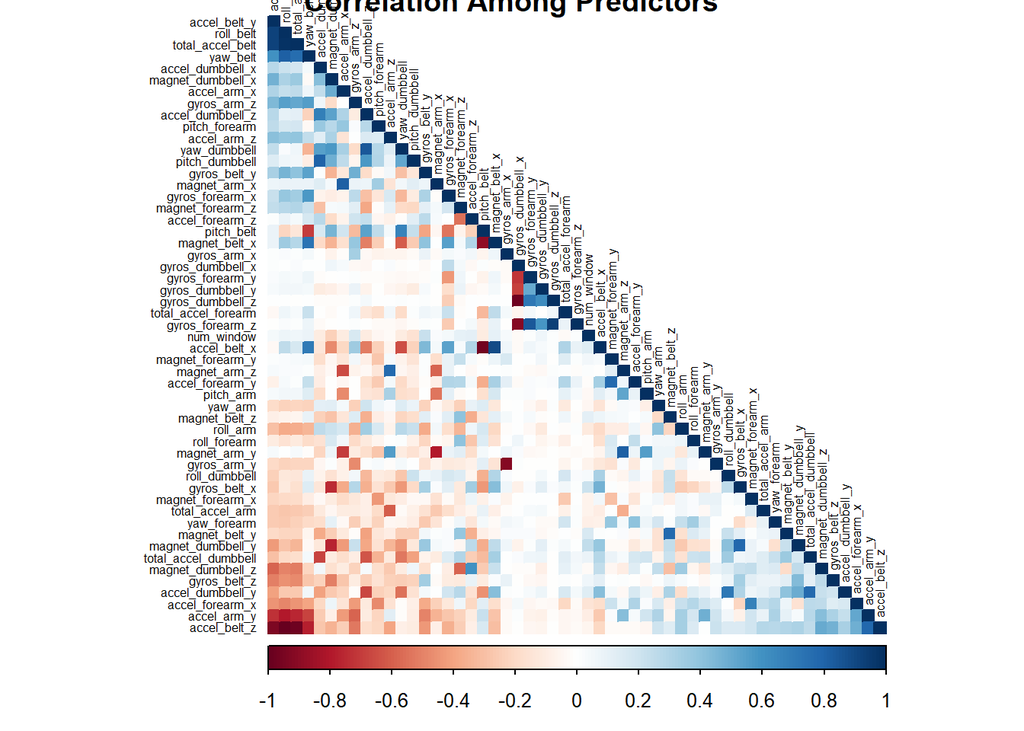

```r
library(corrplot)
corr <- corrplot(cor(training[,-54]), order = "FPC", method = "color", type = "lower", tl.cex = .5, tl.col = "black", title = "Correlation Among Predictors")
```

```r
listCorr <- findCorrelation(corr, cutoff = .7)
namesCorr <- names(training)[listCorr]
```

## B) Coefficient of Variation

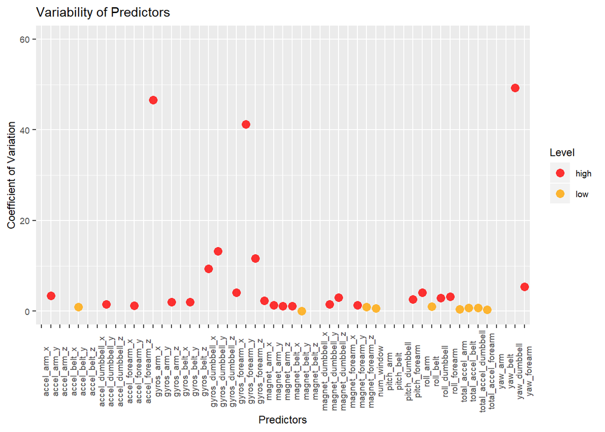

```r
library(ggplot2)

StdDev <- apply(training[,-54], 2, sd)
MeanSub <- apply(training[,-54],2, mean)
CoeffVar <- StdDev/MeanSub

StdDF <- data.frame(names(training[,-54]), CoeffVar)

StdDF$Level <- ifelse(abs(StdDF$CoeffVar) <= 1, StdDF$Level <- "low", StdDF$Level <- "high")
names(StdDF) <- c("Predictor", "Coefficient.Variation", "Level")

CVplot <- ggplot(StdDF, aes(Predictor, Coefficient.Variation, color = Level)) + geom_point(pch=16, cex=3, alpha=.8)+ scale_color_manual(values = c("red", "orange"))+ ylim(0,60) + theme(axis.text.x = element_text(angle = 90)) + theme(text = element_text(size=9)) + labs(x="Predictors", y="Coefficient of Variation") + ggtitle("Variability of Predictors")

listCV <- subset(StdDF, StdDF$Coefficient.Variation > 1)
rowCV <- nrow(listCV)
print(CVplot)
```